# Assignment_9_Work

Steven Baldwin

First we will look at the predictive power of GPA, GRE and rank over admission individually using logistic regression.

```r
mod1 = glm(admit ~ gpa * rank, data = df, family = "binomial")
df$binom.pred1 <- predict(mod1, type = "response")
df$binom.resid1 <- residuals(mod1, type = "response")

mod2 = glm(admit ~ gre * rank, data = df, family = "binomial")
df$binom.pred2 <- predict(mod2, type = "response")
df$binom.resid2 <- residuals(mod2, type = "response")

mod3 = glm(admit ~ rank, data = df, family = "binomial")
df$binom.pred3 <- predict(mod3, type = "response")
df$binom.resid3 <- residuals(mod3, type = "response")
```

Next I shall run the summary() command on each model to see its strength.  
The predictive power of GPA…

```
##
## Call:
## glm(formula = admit ~ gpa * rank, family = "binomial", data = df)
##
## Deviance Residuals:
##     Min       1Q   Median       3Q      Max
## -1.4947  -0.8871  -0.6654   1.1441   2.1337
##
## Coefficients:
##             Estimate Std. Error z value Pr(>|z|)
## (Intercept)  -3.7164     2.9443  -1.262    0.207
## gpa           1.2697     0.8532   1.488    0.137
## rank         -0.2171     1.1994  -0.181    0.856
## gpa:rank     -0.1062     0.3472  -0.306    0.760
##
## (Dispersion parameter for binomial family taken to be 1)
##
##     Null deviance: 499.98  on 399  degrees of freedom
## Residual deviance: 463.84  on 396  degrees of freedom
## AIC: 471.84
##
## Number of Fisher Scoring iterations: 4
```

The predictive power of GRE score…

```
##
## Call:
## glm(formula = admit ~ gre * rank, family = "binomial", data = df)
##
## Deviance Residuals:
##     Min       1Q   Median       3Q      Max
## -1.4675  -0.8972  -0.6599   1.1862   2.1855
##
## Coefficients:
##               Estimate Std. Error z value Pr(>|z|)
## (Intercept) -1.356e+00  1.687e+00  -0.804    0.421
## gre          3.210e-03  2.732e-03   1.175    0.240
## rank        -5.581e-01  6.712e-01  -0.832    0.406
## gre:rank     7.911e-06  1.091e-03   0.007    0.994
##
## (Dispersion parameter for binomial family taken to be 1)
##
##     Null deviance: 499.98  on 399  degrees of freedom
## Residual deviance: 465.20  on 396  degrees of freedom
## AIC: 473.2
##
## Number of Fisher Scoring iterations: 4
```

The predictive power of school rank…

```
##
## Call:
## glm(formula = admit ~ rank, family = "binomial", data = df)
##
## Deviance Residuals:
##     Min       1Q   Median       3Q      Max
## -1.1989  -0.9599  -0.7508   1.1561   1.9365
##
## Coefficients:
##             Estimate Std. Error z value Pr(>|z|)
## (Intercept)   0.6366     0.3061   2.080   0.0375 *
## rank         -0.5863     0.1240  -4.728 2.26e-06 ***
## ---
## Signif. codes:  0 '***' 0.001 '**' 0.01 '*' 0.05 '.' 0.1 ' ' 1
##
## (Dispersion parameter for binomial family taken to be 1)
##
##     Null deviance: 499.98  on 399  degrees of freedom
## Residual deviance: 475.71  on 398  degrees of freedom
## AIC: 479.71
##
## Number of Fisher Scoring iterations: 4
```

These summaries suggest that GPA and GRE are not enough to explain the model alone, though rank is a significant predictor of acceptance. This does not however tell us anything meaningful, we know that hardcore universities are hard to get into.  
The graphs below show admission probability as determined by our models.

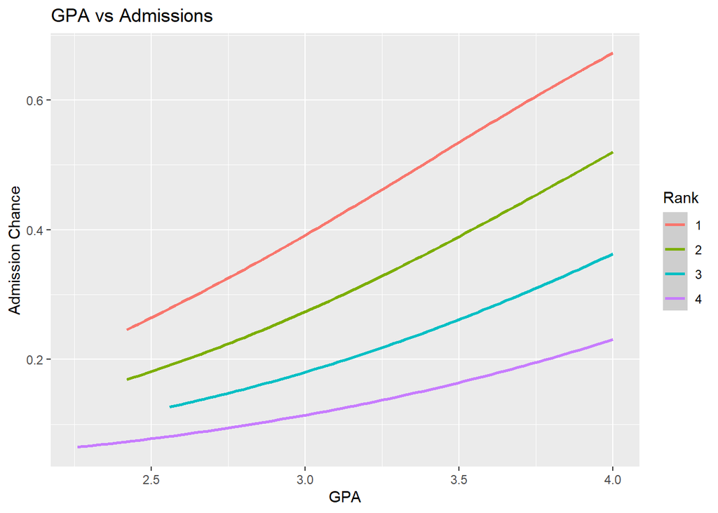

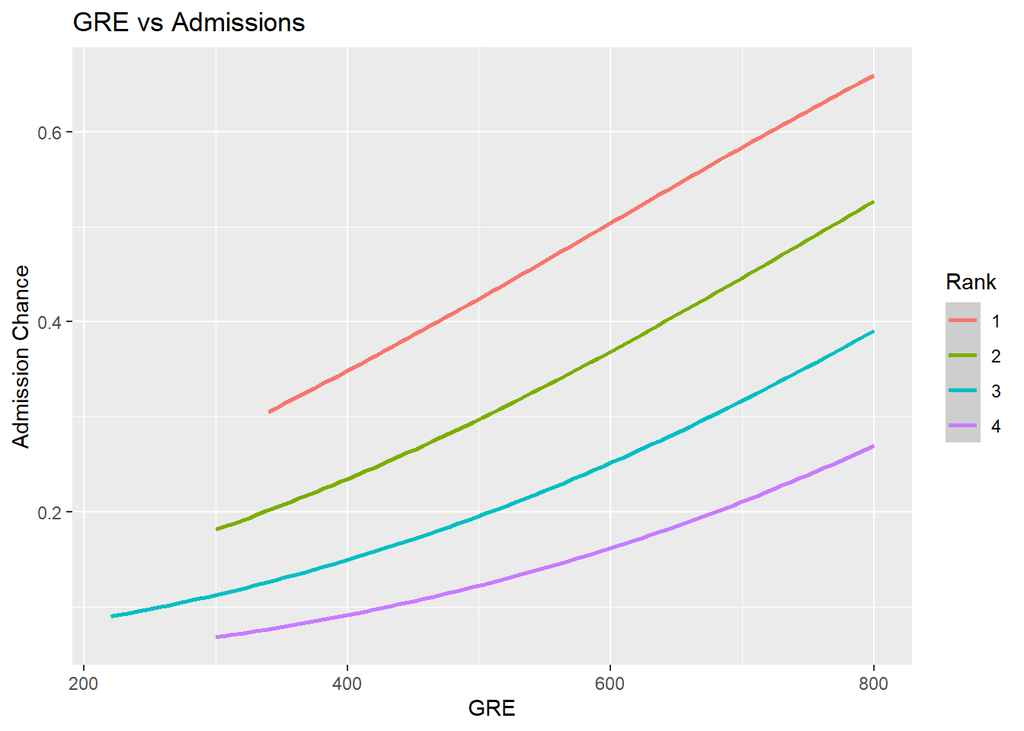

Then I use the stepAIC command on all the predictors added together and it should give me the best model.

```r
combined_model <- glm(data=df,formula=admit ~ gre + gpa * rank,family="binomial")
best_model <- stepAIC(combined_model, direction="both")
```

```
## Start:  AIC=469.33
## admit ~ gre + gpa * rank
##
##            Df Deviance    AIC
## - gpa:rank  1   459.44 467.44
## <none>          459.33 469.33
## - gre       1   463.84 471.84
##
## Step:  AIC=467.44
## admit ~ gre + gpa + rank
##
##            Df Deviance    AIC
## <none>          459.44 467.44
## + gpa:rank  1   459.33 469.33
## - gre       1   463.93 469.93
## - gpa       1   465.20 471.20
## - rank      1   480.34 486.34
```

Here is a summary of this new model.

```
##
## Call:
## glm(formula = admit ~ gre + gpa + rank, family = "binomial",
##     data = df)
##
## Deviance Residuals:
##     Min       1Q   Median       3Q      Max
## -1.5802  -0.8848  -0.6382   1.1575   2.1732
##
## Coefficients:
##              Estimate Std. Error z value Pr(>|z|)
## (Intercept) -3.449548   1.132846  -3.045  0.00233 **
## gre          0.002294   0.001092   2.101  0.03564 *
## gpa          0.777014   0.327484   2.373  0.01766 *
## rank        -0.560031   0.127137  -4.405 1.06e-05 ***
## ---
## Signif. codes:  0 '***' 0.001 '**' 0.01 '*' 0.05 '.' 0.1 ' ' 1
##
## (Dispersion parameter for binomial family taken to be 1)
##
##     Null deviance: 499.98  on 399  degrees of freedom
## Residual deviance: 459.44  on 396  degrees of freedom
## AIC: 467.44
##
## Number of Fisher Scoring iterations: 4
```

Here is the (hopefully) best model plotted on a graph of GPA vs Admission Rate.

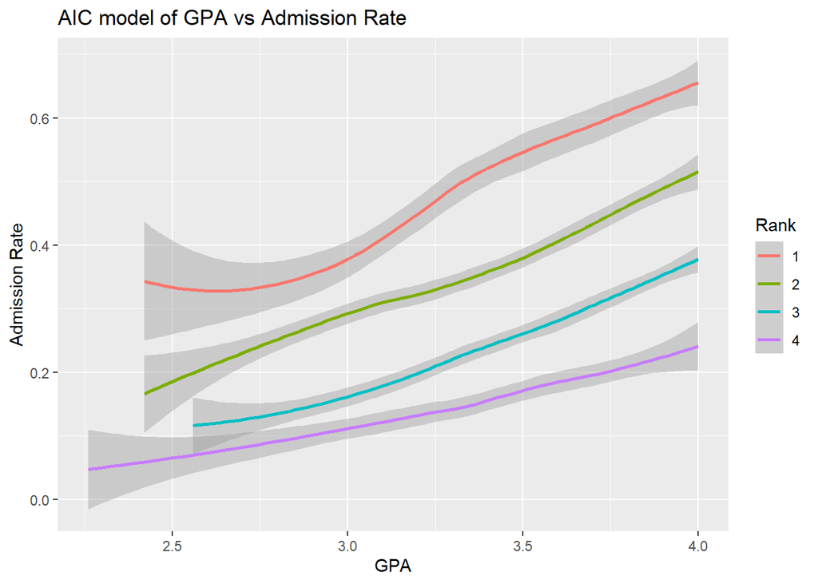

Here is that same model with GRE vs Admission Rate instead.

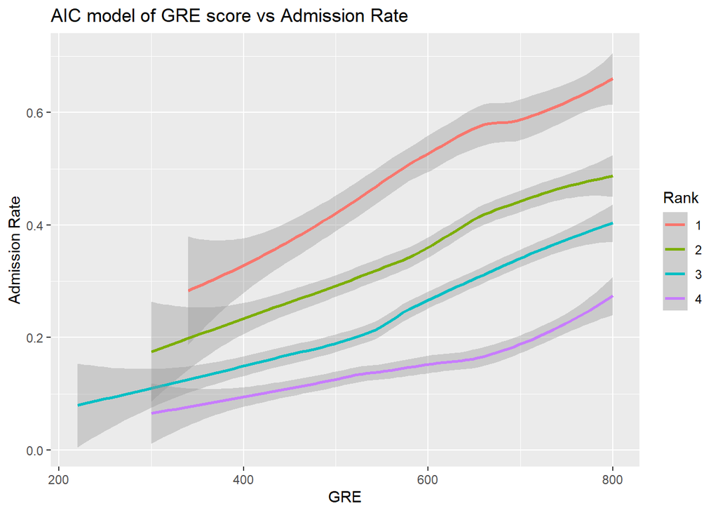

And now to compare our three important models with anova tests to see if they have quality differences.  
Anova comparison of the GPA explanatory model (model one) vs the GRE variant (model two)

```
## Analysis of Deviance Table
##
## Model 1: admit ~ gpa * rank
## Model 2: admit ~ gre * rank
##   Resid. Df Resid. Dev Df Deviance
## 1       396     463.84
## 2       396     465.20  0  -1.3637
```

Anova comparison of model one against the stepAIC generated one.

```
## Analysis of Deviance Table
##
## Model 1: admit ~ gpa * rank
## Model 2: admit ~ gre + gpa + rank
##   Resid. Df Resid. Dev Df Deviance
## 1       396     463.84
## 2       396     459.44  0   4.3983
```

Anova comparison of model two against the stepAIC model.

```
## Analysis of Deviance Table
##
## Model 1: admit ~ gre * rank
## Model 2: admit ~ gre + gpa + rank
##   Resid. Df Resid. Dev Df Deviance
## 1       396     465.20
## 2       396     459.44  0    5.762
```

MSE for each model

Model one MSE:

```
## [1] 1.1596
```

Model two MSE:

```
## [1] 1.163009
```

Model three MSE:

```
## [1] 1.148604
```